# Transmission analysis

Karim

### **1. data quality control**

This includes SNPs filtration based on their MAF (minor allele frequencies), their percentage of missing genotypes (missingness) as well as the filtration of isolates based on missingness.  
**Function name:** *Filter_data.R*  
**Parameters:**  
- *the full path to the input VCF file*  
- *the MAF cut-off*  
- *the missingness cut-off*  
- *the path to the folder where to store the output files*  
- *the numder of threads*  
**Outputs:** *2 `pdf` files (plots of SNPs and isolates missingness and MAF) and a text file named `MyGenotype.txt`*  
**Example:**

```bash
Rscript Filter_data.R Data/file.vcf.gz 0.01 20 Results/ 15
```

### **2. estimation of the complexity of infection (COI)**

The input VCF file will be filtered so that it contains only the SNPs and isolates that have passed the QC step. The filtered VCF file is then used to compute Fws (within sample fixation index) using the `moimix` R package.  
**Function name:** *Compute_COI.R*  
**Parameters:**  
- *the full path to the filtered genotype file*  
- *the full path to the input VCF file*  
- *the sample metadata file*  
- *the file that contains the order in which you wish your population to be shown in the output plot, 1 population per line*  
**Outputs:** *the filtered VCF file (file with a prefix `Passed_QC_genotypes`), 2 `pdf` files (Fws plots)*  
**Example:**

```bash
Rscript Compute_COI.R Results/MyGenotype.txt Data/MyDelgeme4.vcf.gz Data/SampleMetadata.txt Data/Pop_Order.txt
```

### **3. construction of the input files for relatedness inference**

11 regions of the genome that are associated with drug resistance are first discarded. Then the reference alleles are recoded as `0`, the alternate alleles as `1`. We defined 3 methods of recoding the mixed genotypes:  
mixed genotypes replaced by the minor allele calculated across all samples for a given SNPs (`minor_David`)  
mixed genotypes considered as a third allele and recoded as 2 (`raw`)  
mixed genotypes replaced by the minor allele calculated based on the allelic depth on a given isolates at a particular SNP (`minor_Karim`)  
Note that for the first and third method, when the frequencies of the 2 alleles are the same, it is recoded based on a Bernoulli distribution.  
**Function name:** *Construct_Genotype_File.R*  
**Parameters:**  
- *the full path to the filtered VCF file*  
- *the full path to the output files directory*  
- *the full path to the file with sample metadata file*  
- *full path to the file with genomic locations of the regions to be discarded*  
- *the mixed genotypes recoding method*  
**Outputs:** *creates `RDS` files with the recoded genotype data, 1 for each population*  
**Example:**

```bash
Rscript Construct_Genotype_File.R Results/Passed_QC_genotypes.vcf.gz Results/GenotypeFiles Data/SampleMetadata.txt Data/Resistance_Gene.txt raw
```

### **4. Inference of relatedness between all pairs of populations**

We estimated relatedness between pairs of isolates from 2 distinct populations based on the method proposed by Aimee Taylor and Coauthors https://journals.plos.org/plosgenetics/article?id=10.1371/journal.pgen.1009101  
Between every pairs of population, the relatedness is evaluated using data from 5 MAF cut-offs (set of SNPs with MAF>0%, MAF>10%, MAF>20%, MAF>30%, MAF>40%)  
Before running this stage, make sure the `runSim.sh` is edited according to your HPC specifications.  
**Function name:** *Run_Relatedness.R*  
**Parameters:**  
- *the full path to the folder with the recoded data*  
- *the full path to the output files directory*  
- *the full path to the file with population order*  
- *the mixed genotypes recoding method*  
**Outputs:** *creates `RDS` files within different folders, 1 for each pair of populations*  
**Example:**

```bash
Rscript Run_Relatedness.R /lustre/scratch117/casm/team273/km28/Karim/transmission_analysis/Results/Raw_Genotypes /lustre/scratch117/casm/team273/km28/Karim/transmission_analysis/Results/IBD_folder /lustre/scratch117/casm/team273/km28/Karim/transmission_analysis/Data/Pop_Order.txt raw
```

### **5. Summarizing the relatedness files from each pairs of populations**

When estimating relatedness, pairs of samples from 2 populations are splitted and stored into separated RDS files. Here, we will concatenate these files and form one RDS file for each MAF cut-off.  
**Function name:** *Summarize_IBD_Files.R*  
**Parameters:**  
- *the full path to the input folder*  
- *the full path to the output files directory*  
**Outputs:** *creates `RDS` files within output folders*  
**Example:**

```bash
Rscript Summarize_IBD_Files.R /lustre/scratch117/casm/team273/km28/Karim/transmission_analysis/Results/IBD_folder/From_raw_Data /lustre/scratch117/casm/team273/km28/Karim/transmission_analysis/Results/IBD_folder/From_raw_Data/Summarized
```

### **6. Determination of the percentage of highly related infections pairs**

We set a relatedness cut-off (in our case, we varied the cut-off from 0.2 to 0.6 by step of 0.1) and considered any pairs of infection with a relatedness value greater than or equal to this cut-off as a highly related pair of infections. If your samples were collected in different years, the relatedness data will be summarized in a way that for pair of populations, relatedness values will be reported between the different sampling years.  
**Function name:** *Identify_HRPI.R*  
**Parameters:**  
- *the full path to the folder with the summarized data*  
- *the full path to the file with the sample metadata file*  
**Outputs:** *creates several `RDS` files within output folders. Among these, will be interested in the once with a suffix `_All_Pairs.RDS`*  
**Example:**

```bash
Rscript Identify_HRPI.R /lustre/scratch117/casm/team273/km28/Karim/transmission_analysis/Results/IBD_folder/From_raw_Data/Summarized /lustre/scratch117/casm/team273/km28/Karim/transmission_analysis/Data/SampleMetadata.txt
```

### **7. Combine relatedness files**

Files from the above step (6) will be combined into one single file that will be used for the subsequent analysis. Note that the combined output file is a list of 5 data frames that contain the same information. You can chose any of them for the next stages.  
**Function name:** *Combine_Relatedness_Files.R*  
**Parameters:**  
- *the full path to the folder with the summarized data*  
- *the full path to the file with the physical distances between the sampling sites*  
**Outputs:** *creates `RDS` files within a folder named `Combined/`*  
**Example:**

```bash
Rscript Combine_Relatedness_Files.R /lustre/scratch117/casm/team273/km28/Karim/transmission_analysis/Results/IBD_folder/From_raw_Data/Summarized /lustre/scratch117/casm/team273/km28/Karim/transmission_analysis/Data/PhysicalDistanceBetweenLocations.txt
```

### **9. Convert relatedness data frame into matrix**

In order to plot the relatedness between 1 isolate and others, the data needs to be converted into a matrix.  
**Function name:** *Create_relatedness_matrix.R*  
**Parameters:**  
- *the full path to the relatedness file*  
- *the full path to the file sample metadata*  
- *the MAF cut-off*  
- *the path to the output folder*  
- *the output file prefix*  
**Outputs:** *creates an `RDS` file with the prefix chosen by the user*  
**Example:**

```bash
Rscript Create_relatedness_matrix.R /lustre/scratch117/casm/team273/km28/Karim/transmission_analysis/Results/RelatednessFolder/All_Relatedness_From_Raw.RDS /lustre/scratch117/casm/team273/km28/Karim/transmission_analysis/Data/SampleMetadata.txt 0.3 /lustre/scratch117/casm/team273/km28/Karim/transmission_analysis/Results/RelatednessFolder rMatrixFrom_Raw
```

###### **9.1. drawing the mean relatedness as a heatmap**

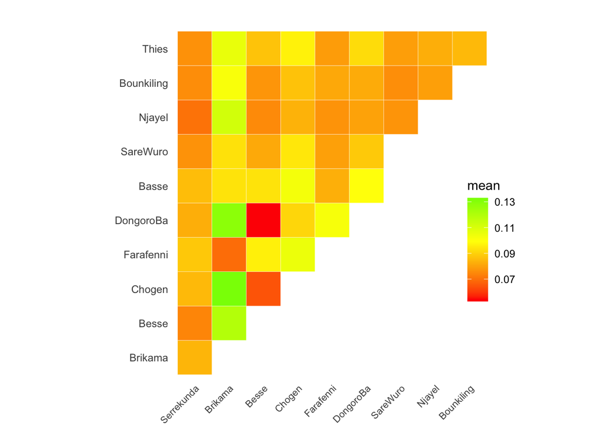

##### **9.2. population structure**

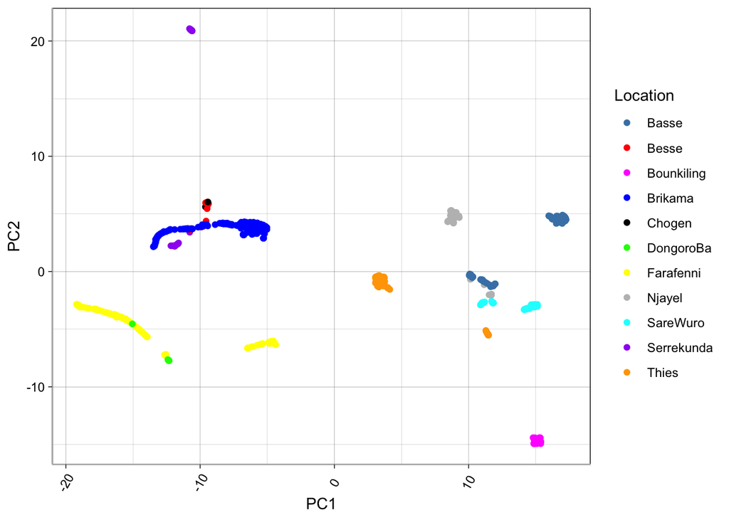

###### **9.3. determination of the proportion of HRI between pairs of populations**

proportion of HRI between locations

| site1 | site2 | #HRI | region1 | region2 | #totalPairs | pHRI |
| --- | --- | --- | --- | --- | --- | --- |
| Basse | Njayel | 10 | east | east | 9360 | 0.0010684 |
| Basse | SareWuro | 37 | east | east | 7254 | 0.0051006 |
| Basse | Thies | 1 | east | sen | 10764 | 0.0000929 |
| Besse | Bounkiling | 2 | west | sen | 1003 | 0.0019940 |
| Besse | Chogen | 4 | west | center | 243 | 0.0164609 |
| Besse | DongoroBa | 2 | west | center | 326 | 0.0061350 |
| Besse | Njayel | 11 | west | east | 2482 | 0.0044319 |
| Besse | SareWuro | 4 | west | east | 1932 | 0.0020704 |
| Besse | Thies | 1 | west | sen | 1564 | 0.0006394 |
| Brikama | Basse | 1 | west | east | 26910 | 0.0000372 |
| Brikama | Besse | 14 | west | west | 5020 | 0.0027888 |
| Brikama | Chogen | 11 | west | center | 2364 | 0.0046531 |
| Brikama | DongoroBa | 13 | west | center | 3268 | 0.0039780 |
| Brikama | Farafenni | 51 | west | center | 36110 | 0.0014124 |
| Brikama | Njayel | 56 | west | east | 23528 | 0.0023801 |
| Chogen | DongoroBa | 8 | center | center | 153 | 0.0522876 |
| Chogen | Njayel | 4 | center | east | 1164 | 0.0034364 |
| DongoroBa | Njayel | 4 | center | east | 1558 | 0.0025674 |
| Njayel | SareWuro | 25 | east | east | 9276 | 0.0026951 |
| Njayel | Thies | 5 | east | sen | 7360 | 0.0006793 |
| SareWuro | Thies | 1 | east | sen | 5704 | 0.0001753 |
| Thies | Bounkiling | 4 | sen | sen | 5428 | 0.0007369 |

proportion of HRI between regions

[output not shown]

### **10. spatial analysis (drawing connectivity using the proportion of HRI)**

```
## [1] ""
```

[output not shown]

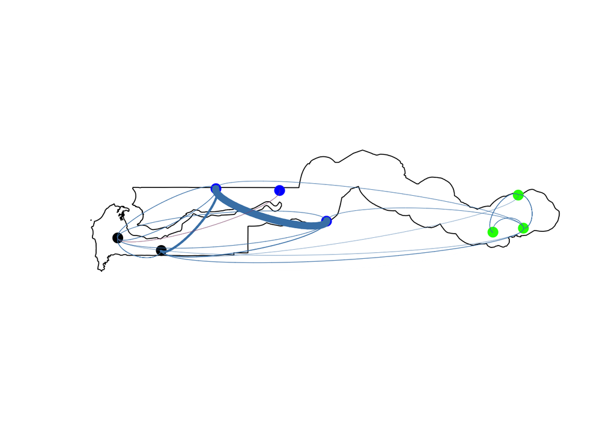

```
## [1] ""
```

#pairs in eastern Gambia with GPS data

| villageCode1 | villageCode2 | N |
| --- | --- | --- |
| J | L | 4 |
| J | M | 3 |
| K | L | 51 |
| K | M | 7 |

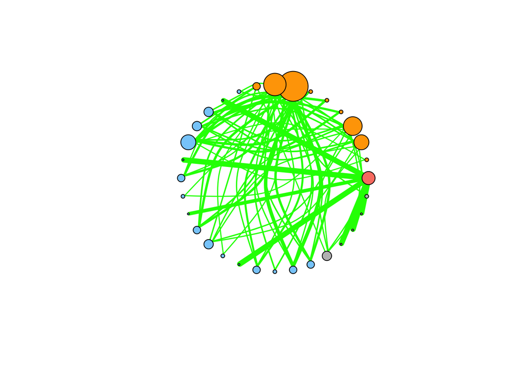

[interactive chart not shown]